# Prosody: Scaled experiment

# Reading in data

```r
# setwd("/Users/seantrott/Dropbox/UCSD/Research/IndirectSpeechActs/Prosody/pros_scaled/src/analysis/behavioral/")
df_processed = read_csv("../../../data/processed/behavioral/pros_scaled_processed.csv")
nrow(df_processed)
```

```
## [1] 18368
```

```r
length(unique(df_processed$subject))
```

```
## [1] 82
```

```r
# Filter to just critical stims
df_critical = df_processed %>%
  # Critical trials
  filter(condition %in% c("statement", "request", "question")) %>%
  # The second of each nested trial (i.e., where participant has a response)
  filter(!is.na(response))
```

## Checking over data

```r
table(df_critical$speaker)
```

```
##
##   1   2   3   4   5   6   7   8   9  11  17  18  19  20  21  22  24  25
## 492 480 528 480 588 420 408 636 480 372 468 564 516 420 420 528 564 492
```

```r
length(unique(df_critical$subject))
```

```
## [1] 82
```

## Exclusion

We exclude participants who identify as non-native speakers:

```r
df_critical = df_critical %>%
  filter(Native_Speaker != "No") ## Corrected
nrow(df_critical)
```

```
## [1] 8748
```

```r
length(unique(df_critical$subject))
```

```
## [1] 81
```

We also exclude participants with any missing data:

```r
# 9 speakers * 12 utterances = 108 items
TOTAL = 108

df_counts = df_critical %>%
  group_by(subject) %>%
  summarise(count = n())
df_exclude = df_counts %>%
  filter(count < TOTAL)

df_critical = df_critical %>%
  filter((subject %in% df_exclude$subject) == FALSE)
nrow(df_critical)
```

```
## [1] 8748
```

```r
length(unique(df_critical$subject))
```

```
## [1] 81
```

## Additional preprocessing

```r
## Here, we reset condition labels (Request vs. Non-Request)
df_critical$Intent = factor(fct_recode(df_critical$condition,
                             "Request" = "request",
                             "Non-Request" = "statement",
                             "Non-Request" = "question"), levels = c("Non-Request", "Request"))

## Here, we reset response labels (Request vs. Non-Request)
df_critical$Interpretation = factor(df_critical$response, levels = c("Non-Request", "Request"))


## We also create several more indicator variables for ease of plotting and merging
df_critical = df_critical %>%
  mutate(correct = Interpretation == Intent) %>%
  mutate(correct_numeric = as.numeric(correct),
         ## 1 for Request, 0 for Non-Request
         response_numeric = as.numeric(Interpretation) - 1) %>%
  mutate(topic = tolower(topic))

# For merging with norming data
df_critical$topic = fct_recode(df_critical$topic,
                               "temperature" = "temp")
```

## Merge with norming data

```r
df_normed = read_csv("../../../data/processed/norming/item_means.csv")
df_merged = df_critical %>%
  inner_join(df_normed, by = c("form", "topic"))

nrow(df_critical)
```

```
## [1] 8748
```

```r
nrow(df_merged)
```

```
## [1] 8748
```

```r
df_normed$topic %in% df_merged$topic
```

```
##  [1] TRUE TRUE TRUE TRUE TRUE TRUE TRUE TRUE TRUE TRUE TRUE TRUE
```

# Primary analyses

## Q1: Does Intent predict response?

### Descriptive

```r
mean(df_merged$correct)
```

```
## [1] 0.5491541
```

```r
df_merged %>%
  group_by(Intent) %>%
  summarise(mean_request = mean(response_numeric))
```

```
## # A tibble: 2 x 2
##   Intent      mean_request
##   <fct>              <dbl>
## 1 Non-Request        0.477
## 2 Request            0.576
```

```r
df_merged %>%
  group_by(form, Intent) %>%
  summarise(mean_request = mean(response_numeric))
```

```
## # A tibble: 4 x 3
## # Groups:   form [2]
##   form            Intent      mean_request
##   <chr>           <fct>              <dbl>
## 1 conventional    Non-Request        0.621
## 2 conventional    Request            0.759
## 3 nonconventional Non-Request        0.356
## 4 nonconventional Request            0.422
```

```r
df_merged %>%
  group_by(form) %>%
  summarise(mean_request = mean(response_numeric))
```

```
## # A tibble: 2 x 2
##   form            mean_request
##   <chr>                  <dbl>
## 1 conventional           0.690
## 2 nonconventional        0.389
```

### Visualization

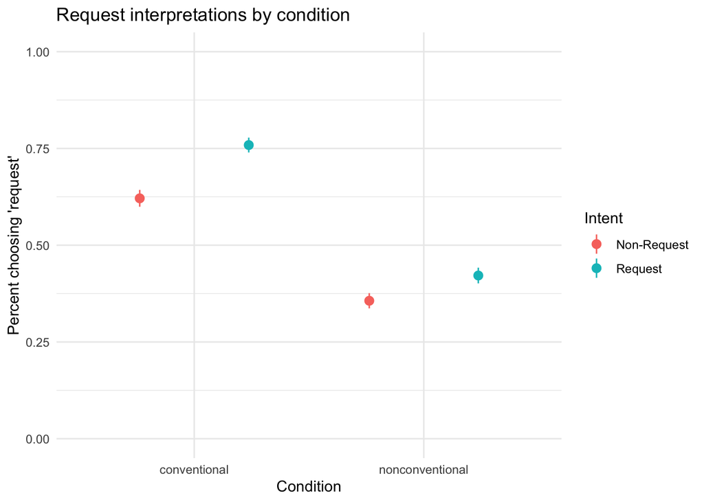

```r
df_merged %>%
  ggplot(aes(x = form, y = response_numeric, color = Intent)) +
  stat_summary (fun = function(x){mean(x)},
                fun.min = function(x){mean(x) - 2*sd(x)/sqrt(length(x))},
                fun.max = function(x){mean(x) + 2*sd(x)/sqrt(length(x))},
                geom= 'pointrange',
                position=position_dodge(width=0.95)) +
  theme_minimal() +
  ggtitle("Request interpretations by condition") +
  xlab("Condition") +
  ylab("Percent choosing 'request'") +
  scale_y_continuous(limits = c(0, 1))
```

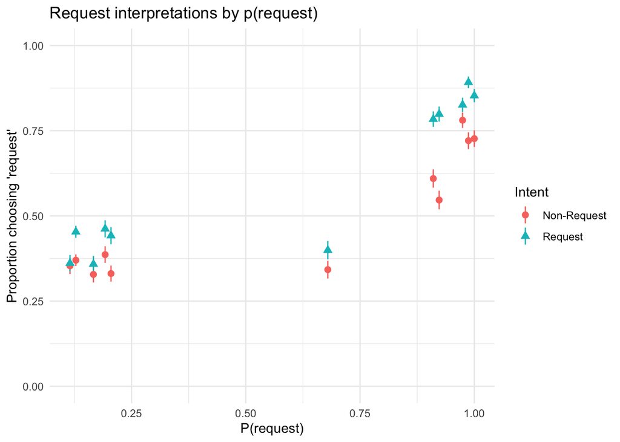

```r
df_merged %>%
  ggplot(aes(x = mean_request,
             y = response_numeric,
             color = Intent,
             shape = Intent)) +
  stat_summary (fun = function(x){mean(x)},
                fun.min = function(x){mean(x) - 1*sd(x)/sqrt(length(x))},
                fun.max = function(x){mean(x) + 1*sd(x)/sqrt(length(x))},
                geom= 'pointrange') +
  theme_minimal() +
  ggtitle("Request interpretations by p(request)") +
  xlab("P(request)") +
  ylab("Proportion choosing 'request'") +
  scale_y_continuous(limits = c(0, 1))
```

```r
ggsave("../../../Figures/exp_scaled_priors.png", dpi = 300)
df_merged %>%
  group_by(mean_request) %>%
  summarise(p_request = mean(response_numeric),
            count = n())
```

```
## # A tibble: 11 x 3
##    mean_request p_request count
##           <dbl>     <dbl> <int>
##  1        0.115     0.357   792
##  2        0.128     0.412  1584
##  3        0.167     0.343   792
##  4        0.192     0.424   792
##  5        0.205     0.386   792
##  6        0.679     0.371   666
##  7        0.910     0.697   666
##  8        0.923     0.673   666
##  9        0.974     0.803   666
## 10        0.987     0.806   666
## 11        1         0.790   666
```

### Analysis

We ask whether `Intent` explains variance in `Response`, above and beyond other factors like `Prior request probability` and `Form`.

```r
model_full = glmer(data=df_merged,
                Interpretation ~ Intent + form + mean_request +
                  (1 + Intent | topic) +
             (1 + Intent + mean_request | subject) +
               (1 | speaker),
           control=glmerControl(optimizer="bobyqa"),
         family=binomial())

summary(model_full)
```

```
## Generalized linear mixed model fit by maximum likelihood (Laplace
##   Approximation) [glmerMod]
##  Family: binomial  ( logit )
## Formula: Interpretation ~ Intent + form + mean_request + (1 + Intent |
##     topic) + (1 + Intent + mean_request | subject) + (1 | speaker)
##    Data: df_merged
## Control: glmerControl(optimizer = "bobyqa")
##
##      AIC      BIC   logLik deviance df.resid
##   9701.6   9800.7  -4836.8   9673.6     8734
##
## Scaled residuals:
##     Min      1Q  Median      3Q     Max
## -4.6218 -0.7268  0.2055  0.7006  6.1362
##
## Random effects:
##  Groups  Name          Variance Std.Dev. Corr
##  subject (Intercept)   3.3700   1.8358
##          IntentRequest 0.4059   0.6371   -0.39
##          mean_request  4.2426   2.0598   -0.86  0.19
##  speaker (Intercept)   0.1006   0.3172
##  topic   (Intercept)   0.0896   0.2993
##          IntentRequest 0.1046   0.3235   -0.72
## Number of obs: 8748, groups:  subject, 81; speaker, 18; topic, 12
##
## Fixed effects:
##                     Estimate Std. Error z value Pr(>|z|)
## (Intercept)          -5.5141     0.8753  -6.300 2.98e-10 ***
## IntentRequest         0.6031     0.1308   4.611 4.01e-06 ***
## formnonconventional   3.4149     0.7408   4.610 4.04e-06 ***
## mean_request          6.9051     0.9708   7.113 1.14e-12 ***
## ---
## Signif. codes:  0 '***' 0.001 '**' 0.01 '*' 0.05 '.' 0.1 ' ' 1
##
## Correlation of Fixed Effects:
##             (Intr) IntntR frmnnc
## IntentReqst -0.124
## frmnncnvntn -0.935  0.007
## mean_requst -0.970  0.031  0.913
```

```r
model_no_intent = glmer(data=df_merged,
                Interpretation ~ form + mean_request +
                  (1 + Intent | topic) +
             (1 + Intent + mean_request | subject) +
               (1 | speaker),
           control=glmerControl(optimizer="bobyqa"),
         family=binomial())


anova(model_full, model_no_intent)
```

```
## Data: df_merged
## Models:
## model_no_intent: Interpretation ~ form + mean_request + (1 + Intent | topic) +
## model_no_intent:     (1 + Intent + mean_request | subject) + (1 | speaker)
## model_full: Interpretation ~ Intent + form + mean_request + (1 + Intent |
## model_full:     topic) + (1 + Intent + mean_request | subject) + (1 | speaker)
##                 npar    AIC    BIC  logLik deviance Chisq Df Pr(>Chisq)
## model_no_intent   13 9713.7 9805.7 -4843.9   9687.7
## model_full        14 9701.6 9800.7 -4836.8   9673.6 14.07  1  0.0001762 ***
## ---
## Signif. codes:  0 '***' 0.001 '**' 0.01 '*' 0.05 '.' 0.1 ' ' 1
```

We can also visualize the coefficients from this model:

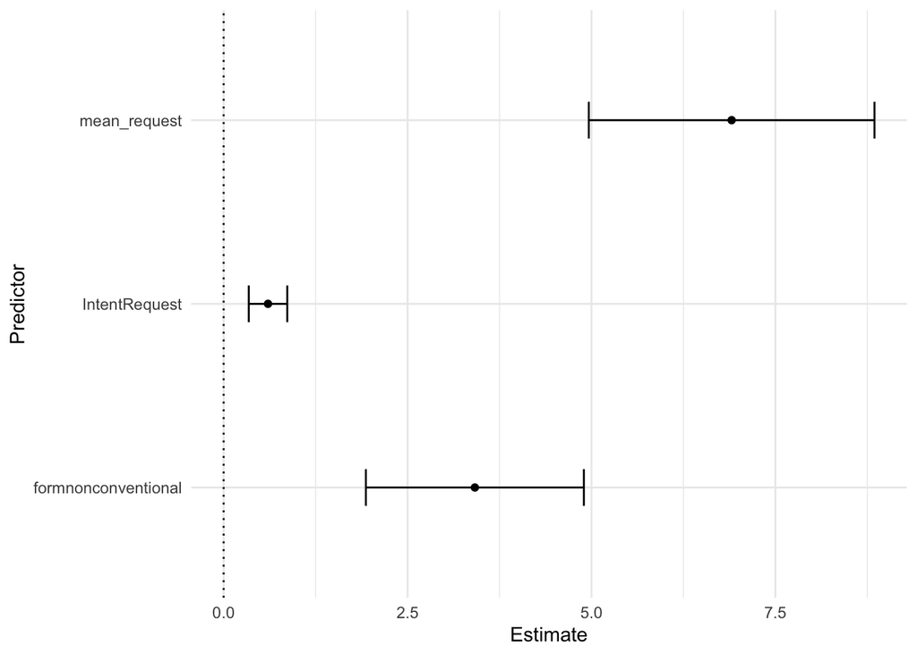

```r
df_tidy = broom.mixed::tidy(model_full)

df_tidy %>%
  filter(effect == "fixed") %>%
  filter(term != "(Intercept)") %>%
  ggplot(aes(x = term,
             y = estimate)) +
  geom_point() +
  coord_flip() +
  geom_hline(yintercept = 0, linetype = "dotted") +
  geom_errorbar(aes(ymin = estimate - 2*std.error,
                    ymax = estimate + 2*std.error),
                width=.2,
                position=position_dodge(.9)) +
  labs(x = "Predictor",
       y = "Estimate") +
  theme_minimal()
```

## Q2: Which acoustic features predict pragmatic interpretation?

### Load acoustic features data

```r
df_audio = read_csv("../../../data/processed/audio/audio_features_scaled_stimuli.csv")
df_audio$label = factor(df_audio$label)

df_audio$condition = fct_recode(df_audio$label,
                            "Request" = "ir",
                            "Non-Request" = "literal")
df_audio$speaker = factor(df_audio$speaker)

df_audio = df_audio %>%
  group_by(speaker) %>%
  mutate(mean_f0_z_score = scale(mean_f0),
         duration_f0_z_score = scale(duration_f0),
         range_f0_z_score = scale(range_f0),
         sd_f0_z_score = scale(sd_f0),
         slope_f0_z_score = scale(slope_f0),
         mean_intensity_z_score = scale(mean_intensity),
         sd_intensity_z_score = scale(sd_intensity)
         )
```

### Merge with behavioral data

```r
df_audio = df_audio %>%
  select(condition, speaker, stimNum, mean_f0_z_score, duration_f0_z_score, range_f0_z_score,
         sd_f0_z_score, slope_f0_z_score, mean_intensity_z_score, sd_intensity_z_score) %>%
  mutate(speaker = factor(speaker))
nrow(df_audio)
```

```
## [1] 549
```

```r
df_merged_audio = df_merged %>%
  mutate(speaker = factor(speaker)) %>%
  inner_join(df_audio, on = c("condition", "speaker", "stimNum"))
nrow(df_merged_audio)
```

```
## [1] 8748
```

```r
df_merged_audio$form = factor(df_merged_audio$form, levels=c("nonconventional", "conventional"))
```

### Analysis

To do this, we compare each model in turn, successively dropping out different acoustic features.

### Do the features predict participants' predicted label?

```r
model_response_full = glmer(data = df_merged_audio,
                      Interpretation ~ slope_f0_z_score * form +
                        mean_f0_z_score * form +
                       duration_f0_z_score * form +
                       range_f0_z_score * form +
                       sd_f0_z_score * form +
                       mean_intensity_z_score * form +
                       sd_intensity_z_score * form +
                        (1 | subject) +
                        (1 | speaker) +
                        (1 | stimNum),
                       control=glmerControl(optimizer="bobyqa"),
                       family = binomial())


summary(model_response_full)
```

```
## Generalized linear mixed model fit by maximum likelihood (Laplace
##   Approximation) [glmerMod]
##  Family: binomial  ( logit )
## Formula: Interpretation ~ slope_f0_z_score * form + mean_f0_z_score *
##     form + duration_f0_z_score * form + range_f0_z_score * form +
##     sd_f0_z_score * form + mean_intensity_z_score * form + sd_intensity_z_score *
##     form + (1 | subject) + (1 | speaker) + (1 | stimNum)
##    Data: df_merged_audio
## Control: glmerControl(optimizer = "bobyqa")
##
##      AIC      BIC   logLik deviance df.resid
##   9702.4   9836.9  -4832.2   9664.4     8729
##
## Scaled residuals:
##     Min      1Q  Median      3Q     Max
## -6.8927 -0.7365  0.1927  0.7028  6.8532
##
## Random effects:
##  Groups  Name        Variance Std.Dev.
##  subject (Intercept) 1.06939  1.0341
##  speaker (Intercept) 0.06589  0.2567
##  stimNum (Intercept) 0.40416  0.6357
## Number of obs: 8748, groups:  subject, 81; speaker, 18; stimNum, 12
##
## Fixed effects:
##                                           Estimate Std. Error z value Pr(>|z|)
## (Intercept)                             -0.5203421  0.3121533  -1.667 0.095526
## slope_f0_z_score                        -0.1602573  0.0427888  -3.745 0.000180
## formconventional                         1.7553685  0.4396776   3.992 6.54e-05
## mean_f0_z_score                          0.1484664  0.0487924   3.043 0.002344
## duration_f0_z_score                      0.2461123  0.0438300   5.615 1.96e-08
## range_f0_z_score                        -0.1600429  0.0722821  -2.214 0.026819
## sd_f0_z_score                            0.1313580  0.0737666   1.781 0.074957
## mean_intensity_z_score                   0.0007597  0.0438159   0.017 0.986167
## sd_intensity_z_score                     0.0777487  0.0409345   1.899 0.057519
## slope_f0_z_score:formconventional       -0.2232940  0.0659659  -3.385 0.000712
## formconventional:mean_f0_z_score        -0.2625607  0.0739295  -3.552 0.000383
## formconventional:duration_f0_z_score    -0.7311312  0.0690881 -10.583  < 2e-16
## formconventional:range_f0_z_score        0.4499827  0.1093665   4.114 3.88e-05
## formconventional:sd_f0_z_score          -0.2785151  0.1111955  -2.505 0.012254
## formconventional:mean_intensity_z_score  0.0163770  0.0719212   0.228 0.819874
## formconventional:sd_intensity_z_score   -0.1388614  0.0643287  -2.159 0.030879
##
## (Intercept)                             .
## slope_f0_z_score                        ***
## formconventional                        ***
## mean_f0_z_score                         **
## duration_f0_z_score                     ***
## range_f0_z_score                        *
## sd_f0_z_score                           .
## mean_intensity_z_score
## sd_intensity_z_score                    .
## slope_f0_z_score:formconventional       ***
## formconventional:mean_f0_z_score        ***
## formconventional:duration_f0_z_score    ***
## formconventional:range_f0_z_score       ***
## formconventional:sd_f0_z_score          *
## formconventional:mean_intensity_z_score
## formconventional:sd_intensity_z_score   *
## ---
## Signif. codes:  0 '***' 0.001 '**' 0.01 '*' 0.05 '.' 0.1 ' ' 1
```

```
##
## Correlation matrix not shown by default, as p = 16 > 12.
## Use print(x, correlation=TRUE)  or
##     vcov(x)        if you need it
```

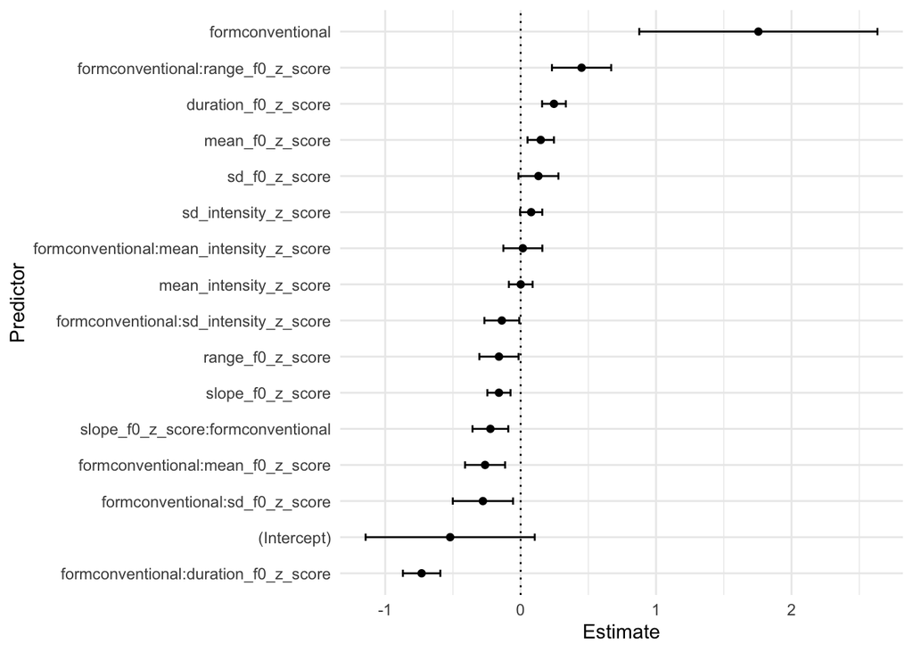

```r
df_tidy = broom.mixed::tidy(model_response_full)

df_tidy %>%
  filter(effect == "fixed") %>%
  ggplot(aes(x = reorder(term, estimate),
             y = estimate)) +
  geom_point() +
  coord_flip() +
  geom_hline(yintercept = 0, linetype = "dotted") +
  geom_errorbar(aes(ymin = estimate - 2*std.error,
                    ymax = estimate + 2*std.error),
                width=.2,
                position=position_dodge(.9)) +
  labs(x = "Predictor",
       y = "Estimate") +
  theme_minimal()
```

#### F0 slope

```r
model_response_no_slope_interaction = glmer(data = df_merged_audio,
                      Interpretation ~ slope_f0_z_score +
                      mean_f0_z_score * form +
                      duration_f0_z_score * form +
                       range_f0_z_score * form +
                       sd_f0_z_score * form +
                       mean_intensity_z_score * form +
                       sd_intensity_z_score * form +
                        (1 | subject) +
                        (1 | speaker) +
                        (1 | stimNum),
                       control=glmerControl(optimizer="bobyqa"),
                       family = binomial())

model_response_no_slope = glmer(data = df_merged_audio,
                      Interpretation ~ mean_f0_z_score * form +
                       duration_f0_z_score * form +
                       range_f0_z_score * form +
                       sd_f0_z_score * form +
                       mean_intensity_z_score * form +
                       sd_intensity_z_score * form +
                        (1 | subject) +
                        (1 | speaker) +
                        (1 | stimNum),
                       control=glmerControl(optimizer="bobyqa"),
                       family = binomial())
```

```r
anova(model_response_full, model_response_no_slope_interaction)
```

```
## Data: df_merged_audio
## Models:
## model_response_no_slope_interaction: Interpretation ~ slope_f0_z_score + mean_f0_z_score * form +
## model_response_no_slope_interaction:     duration_f0_z_score * form + range_f0_z_score * form + sd_f0_z_score *
## model_response_no_slope_interaction:     form + mean_intensity_z_score * form + sd_intensity_z_score *
## model_response_no_slope_interaction:     form + (1 | subject) + (1 | speaker) + (1 | stimNum)
## model_response_full: Interpretation ~ slope_f0_z_score * form + mean_f0_z_score *
## model_response_full:     form + duration_f0_z_score * form + range_f0_z_score * form +
## model_response_full:     sd_f0_z_score * form + mean_intensity_z_score * form + sd_intensity_z_score *
## model_response_full:     form + (1 | subject) + (1 | speaker) + (1 | stimNum)
##                                     npar    AIC    BIC  logLik deviance  Chisq
## model_response_no_slope_interaction   18 9711.9 9839.2 -4837.9   9675.9
## model_response_full                   19 9702.4 9836.9 -4832.2   9664.4 11.415
##                                     Df Pr(>Chisq)
## model_response_no_slope_interaction
## model_response_full                  1  0.0007286 ***
## ---
## Signif. codes:  0 '***' 0.001 '**' 0.01 '*' 0.05 '.' 0.1 ' ' 1
```

```r
anova(model_response_no_slope_interaction, model_response_no_slope)
```

```
## Data: df_merged_audio
## Models:
## model_response_no_slope: Interpretation ~ mean_f0_z_score * form + duration_f0_z_score *
## model_response_no_slope:     form + range_f0_z_score * form + sd_f0_z_score * form + mean_intensity_z_score *
## model_response_no_slope:     form + sd_intensity_z_score * form + (1 | subject) + (1 |
## model_response_no_slope:     speaker) + (1 | stimNum)
## model_response_no_slope_interaction: Interpretation ~ slope_f0_z_score + mean_f0_z_score * form +
## model_response_no_slope_interaction:     duration_f0_z_score * form + range_f0_z_score * form + sd_f0_z_score *
## model_response_no_slope_interaction:     form + mean_intensity_z_score * form + sd_intensity_z_score *
## model_response_no_slope_interaction:     form + (1 | subject) + (1 | speaker) + (1 | stimNum)
##                                     npar    AIC    BIC  logLik deviance  Chisq
## model_response_no_slope               17 9781.1 9901.4 -4873.6   9747.1
## model_response_no_slope_interaction   18 9711.9 9839.2 -4837.9   9675.9 71.257
##                                     Df Pr(>Chisq)
## model_response_no_slope
## model_response_no_slope_interaction  1  < 2.2e-16 ***
## ---
## Signif. codes:  0 '***' 0.001 '**' 0.01 '*' 0.05 '.' 0.1 ' ' 1
```

#### Mean F0

```r
model_response_no_mean_f0_interaction = glmer(data = df_merged_audio,
                      Interpretation ~ slope_f0_z_score * form +
                        mean_f0_z_score +
                       duration_f0_z_score * form +
                       range_f0_z_score * form +
                       sd_f0_z_score * form +
                       mean_intensity_z_score * form +
                       sd_intensity_z_score * form +
                        (1 | subject) +
                        (1 | speaker) +
                        (1 | stimNum),
                       control=glmerControl(optimizer="bobyqa"),
                       family = binomial())

model_response_no_mean_f0 = glmer(data = df_merged_audio,
                      Interpretation ~ slope_f0_z_score * form +
                       duration_f0_z_score * form +
                       range_f0_z_score * form +
                       sd_f0_z_score * form +
                       mean_intensity_z_score * form +
                       sd_intensity_z_score * form +
                        (1 | subject) +
                        (1 | speaker) +
                        (1 | stimNum),
                       control=glmerControl(optimizer="bobyqa"),
                       family = binomial())
```

```r
anova(model_response_full, model_response_no_mean_f0_interaction)
```

```
## Data: df_merged_audio
## Models:
## model_response_no_mean_f0_interaction: Interpretation ~ slope_f0_z_score * form + mean_f0_z_score +
## model_response_no_mean_f0_interaction:     duration_f0_z_score * form + range_f0_z_score * form + sd_f0_z_score *
## model_response_no_mean_f0_interaction:     form + mean_intensity_z_score * form + sd_intensity_z_score *
## model_response_no_mean_f0_interaction:     form + (1 | subject) + (1 | speaker) + (1 | stimNum)
## model_response_full: Interpretation ~ slope_f0_z_score * form + mean_f0_z_score *
## model_response_full:     form + duration_f0_z_score * form + range_f0_z_score * form +
## model_response_full:     sd_f0_z_score * form + mean_intensity_z_score * form + sd_intensity_z_score *
## model_response_full:     form + (1 | subject) + (1 | speaker) + (1 | stimNum)
##                                       npar    AIC    BIC  logLik deviance
## model_response_no_mean_f0_interaction   18 9713.0 9840.4 -4838.5   9677.0
## model_response_full                     19 9702.4 9836.9 -4832.2   9664.4
##                                        Chisq Df Pr(>Chisq)
## model_response_no_mean_f0_interaction
## model_response_full                   12.564  1  0.0003932 ***
## ---
## Signif. codes:  0 '***' 0.001 '**' 0.01 '*' 0.05 '.' 0.1 ' ' 1
```

```r
anova(model_response_no_mean_f0_interaction, model_response_no_mean_f0)
```

```
## Data: df_merged_audio
## Models:
## model_response_no_mean_f0: Interpretation ~ slope_f0_z_score * form + duration_f0_z_score *
## model_response_no_mean_f0:     form + range_f0_z_score * form + sd_f0_z_score * form + mean_intensity_z_score *
## model_response_no_mean_f0:     form + sd_intensity_z_score * form + (1 | subject) + (1 |
## model_response_no_mean_f0:     speaker) + (1 | stimNum)
## model_response_no_mean_f0_interaction: Interpretation ~ slope_f0_z_score * form + mean_f0_z_score +
## model_response_no_mean_f0_interaction:     duration_f0_z_score * form + range_f0_z_score * form + sd_f0_z_score *
## model_response_no_mean_f0_interaction:     form + mean_intensity_z_score * form + sd_intensity_z_score *
## model_response_no_mean_f0_interaction:     form + (1 | subject) + (1 | speaker) + (1 | stimNum)
##                                       npar    AIC    BIC  logLik deviance
## model_response_no_mean_f0               17 9711.8 9832.1 -4838.9   9677.8
## model_response_no_mean_f0_interaction   18 9713.0 9840.4 -4838.5   9677.0
##                                        Chisq Df Pr(>Chisq)
## model_response_no_mean_f0
## model_response_no_mean_f0_interaction 0.7717  1     0.3797
```

#### F0 duration (number of voiced frames)

```r
model_response_no_f0_dur_interaction = glmer(data = df_merged_audio,
                      Interpretation ~ slope_f0_z_score * form +
                        mean_f0_z_score * form +
                       duration_f0_z_score +
                       range_f0_z_score * form +
                       sd_f0_z_score * form +
                       mean_intensity_z_score * form +
                       sd_intensity_z_score * form +
                        (1 | subject) +
                        (1 | speaker) +
                        (1 | stimNum),
                       control=glmerControl(optimizer="bobyqa"),
                       family = binomial())

model_response_no_f0_dur = glmer(data = df_merged_audio,
                      Interpretation ~ slope_f0_z_score * form +
                        mean_f0_z_score * form +
                       range_f0_z_score * form +
                       sd_f0_z_score * form +
                       mean_intensity_z_score * form +
                       sd_intensity_z_score * form +
                        (1 | subject) +
                        (1 | speaker) +
                        (1 | stimNum),
                       control=glmerControl(optimizer="bobyqa"),
                       family = binomial())
```

```r
anova(model_response_full, model_response_no_f0_dur_interaction)
```

```
## Data: df_merged_audio
## Models:
## model_response_no_f0_dur_interaction: Interpretation ~ slope_f0_z_score * form + mean_f0_z_score *
## model_response_no_f0_dur_interaction:     form + duration_f0_z_score + range_f0_z_score * form + sd_f0_z_score *
## model_response_no_f0_dur_interaction:     form + mean_intensity_z_score * form + sd_intensity_z_score *
## model_response_no_f0_dur_interaction:     form + (1 | subject) + (1 | speaker) + (1 | stimNum)
## model_response_full: Interpretation ~ slope_f0_z_score * form + mean_f0_z_score *
## model_response_full:     form + duration_f0_z_score * form + range_f0_z_score * form +
## model_response_full:     sd_f0_z_score * form + mean_intensity_z_score * form + sd_intensity_z_score *
## model_response_full:     form + (1 | subject) + (1 | speaker) + (1 | stimNum)
##                                      npar    AIC    BIC  logLik deviance  Chisq
## model_response_no_f0_dur_interaction   18 9814.7 9942.0 -4889.3   9778.7
## model_response_full                    19 9702.4 9836.9 -4832.2   9664.4 114.22
##                                      Df Pr(>Chisq)
## model_response_no_f0_dur_interaction
## model_response_full                   1  < 2.2e-16 ***
## ---
## Signif. codes:  0 '***' 0.001 '**' 0.01 '*' 0.05 '.' 0.1 ' ' 1
```

```r
anova(model_response_no_f0_dur_interaction, model_response_no_f0_dur)
```

```
## Data: df_merged_audio
## Models:
## model_response_no_f0_dur: Interpretation ~ slope_f0_z_score * form + mean_f0_z_score *
## model_response_no_f0_dur:     form + range_f0_z_score * form + sd_f0_z_score * form + mean_intensity_z_score *
## model_response_no_f0_dur:     form + sd_intensity_z_score * form + (1 | subject) + (1 |
## model_response_no_f0_dur:     speaker) + (1 | stimNum)
## model_response_no_f0_dur_interaction: Interpretation ~ slope_f0_z_score * form + mean_f0_z_score *
## model_response_no_f0_dur_interaction:     form + duration_f0_z_score + range_f0_z_score * form + sd_f0_z_score *
## model_response_no_f0_dur_interaction:     form + mean_intensity_z_score * form + sd_intensity_z_score *
## model_response_no_f0_dur_interaction:     form + (1 | subject) + (1 | speaker) + (1 | stimNum)
##                                      npar    AIC    BIC  logLik deviance  Chisq
## model_response_no_f0_dur               17 9817.8 9938.1 -4891.9   9783.8
## model_response_no_f0_dur_interaction   18 9814.7 9942.0 -4889.3   9778.7 5.1093
##                                      Df Pr(>Chisq)
## model_response_no_f0_dur
## model_response_no_f0_dur_interaction  1     0.0238 *
## ---
## Signif. codes:  0 '***' 0.001 '**' 0.01 '*' 0.05 '.' 0.1 ' ' 1
```

#### Mean Intensity

```r
model_response_no_mean_intensity_interaction = glmer(data = df_merged_audio,
                      Interpretation ~ slope_f0_z_score * form +
                        mean_f0_z_score * form +
                       duration_f0_z_score * form +
                       range_f0_z_score * form+
                       sd_f0_z_score * form +
                       mean_intensity_z_score +
                       sd_intensity_z_score * form +
                        (1 | subject) +
                        (1 | speaker) +
                        (1 | stimNum),
                       control=glmerControl(optimizer="bobyqa"),
                       family = binomial())

model_response_no_mean_intensity = glmer(data = df_merged_audio,
                      Interpretation ~ slope_f0_z_score * form +
                        mean_f0_z_score * form +
                        range_f0_z_score * form+
                        sd_f0_z_score * form +
                       duration_f0_z_score * form +
                       sd_intensity_z_score * form +
                        (1 | subject) +
                        (1 | speaker) +
                        (1 | stimNum),
                       control=glmerControl(optimizer="bobyqa"),
                       family = binomial())
```

```r
anova(model_response_full, model_response_no_mean_intensity_interaction)
```

```
## Data: df_merged_audio
## Models:
## model_response_no_mean_intensity_interaction: Interpretation ~ slope_f0_z_score * form + mean_f0_z_score *
## model_response_no_mean_intensity_interaction:     form + duration_f0_z_score * form + range_f0_z_score * form +
## model_response_no_mean_intensity_interaction:     sd_f0_z_score * form + mean_intensity_z_score + sd_intensity_z_score *
## model_response_no_mean_intensity_interaction:     form + (1 | subject) + (1 | speaker) + (1 | stimNum)
## model_response_full: Interpretation ~ slope_f0_z_score * form + mean_f0_z_score *
## model_response_full:     form + duration_f0_z_score * form + range_f0_z_score * form +
## model_response_full:     sd_f0_z_score * form + mean_intensity_z_score * form + sd_intensity_z_score *
## model_response_full:     form + (1 | subject) + (1 | speaker) + (1 | stimNum)
##                                              npar    AIC    BIC  logLik
## model_response_no_mean_intensity_interaction   18 9700.5 9827.9 -4832.2
## model_response_full                            19 9702.4 9836.9 -4832.2
##                                              deviance  Chisq Df Pr(>Chisq)
## model_response_no_mean_intensity_interaction   9664.5
## model_response_full                            9664.4 0.0515  1     0.8205
```

```r
anova(model_response_no_mean_intensity_interaction, model_response_no_mean_intensity)
```

```
## Data: df_merged_audio
## Models:
## model_response_no_mean_intensity: Interpretation ~ slope_f0_z_score * form + mean_f0_z_score *
## model_response_no_mean_intensity:     form + range_f0_z_score * form + sd_f0_z_score * form + duration_f0_z_score *
## model_response_no_mean_intensity:     form + sd_intensity_z_score * form + (1 | subject) + (1 |
## model_response_no_mean_intensity:     speaker) + (1 | stimNum)
## model_response_no_mean_intensity_interaction: Interpretation ~ slope_f0_z_score * form + mean_f0_z_score *
## model_response_no_mean_intensity_interaction:     form + duration_f0_z_score * form + range_f0_z_score * form +
## model_response_no_mean_intensity_interaction:     sd_f0_z_score * form + mean_intensity_z_score + sd_intensity_z_score *
## model_response_no_mean_intensity_interaction:     form + (1 | subject) + (1 | speaker) + (1 | stimNum)
##                                              npar    AIC    BIC  logLik
## model_response_no_mean_intensity               17 9698.5 9818.8 -4832.3
## model_response_no_mean_intensity_interaction   18 9700.5 9827.9 -4832.2
##                                              deviance  Chisq Df Pr(>Chisq)
## model_response_no_mean_intensity               9664.5
## model_response_no_mean_intensity_interaction   9664.5 0.0429  1     0.8358
```

### Multiple comparisons corrections

```r
p1 = anova(model_response_full, model_response_no_slope_interaction)$`Pr(>Chisq)`[2]
p2 = anova(model_response_no_slope_interaction, model_response_no_slope)$`Pr(>Chisq)`[2]
p3 = anova(model_response_full, model_response_no_mean_f0_interaction)$`Pr(>Chisq)`[2]
p4 = anova(model_response_no_mean_f0_interaction, model_response_no_mean_f0)$`Pr(>Chisq)`[2]
p5 = anova(model_response_full, model_response_no_f0_dur_interaction)$`Pr(>Chisq)`[2]
p6 = anova(model_response_no_f0_dur_interaction, model_response_no_f0_dur)$`Pr(>Chisq)`[2]
p7 = anova(model_response_full, model_response_no_mean_intensity_interaction)$`Pr(>Chisq)`[2]
p8 = anova(model_response_no_mean_intensity_interaction, model_response_no_mean_intensity)$`Pr(>Chisq)`[2]

p.adjust(c(p1, p2, p3, p4, p5, p6, p7, p8), method="holm")
```

```
## [1] 3.642802e-03 2.194868e-16 2.359415e-03 1.000000e+00 9.330393e-26
## [6] 9.518990e-02 1.000000e+00 1.000000e+00
```

## Acoustic feature visualizations

(Note: These visualizations were not part of the original pre-registration file.)

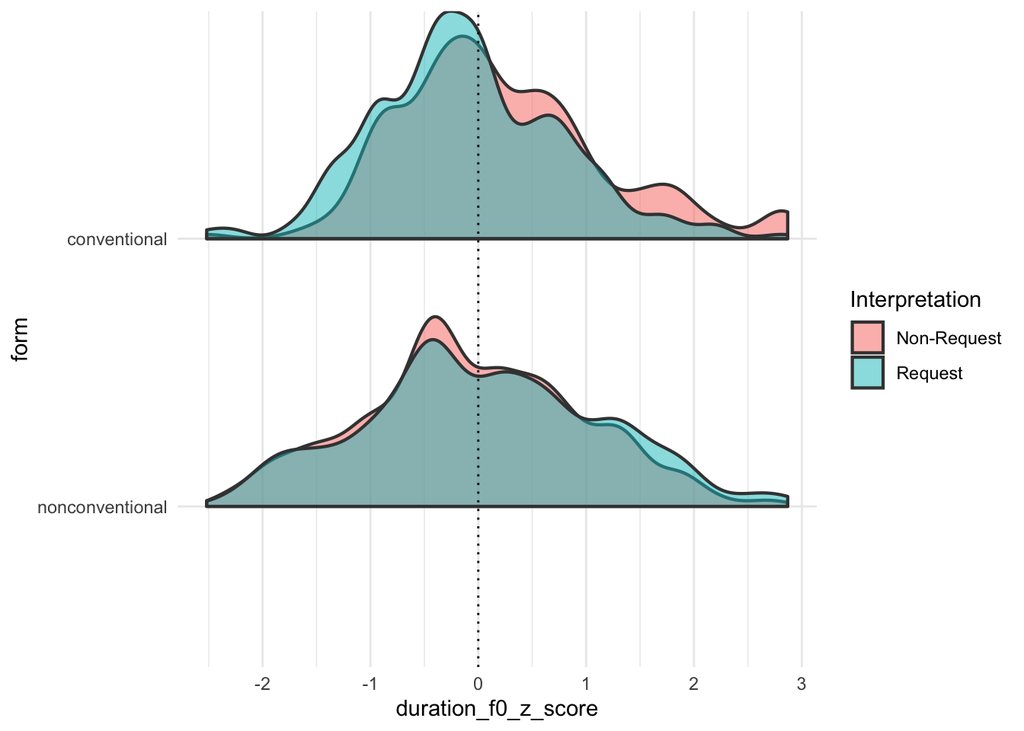

```r
df_merged_audio %>%
  ggplot(aes(x = duration_f0_z_score,
             y = form,
             fill = Interpretation)) +
  geom_density_ridges2(aes(height = ..density..),
                       color=gray(0.25), alpha = 0.5,
                       scale=0.85, size=0.75, stat="density") +
  geom_vline(xintercept = 0, linetype = "dotted") +
  theme_minimal()
```

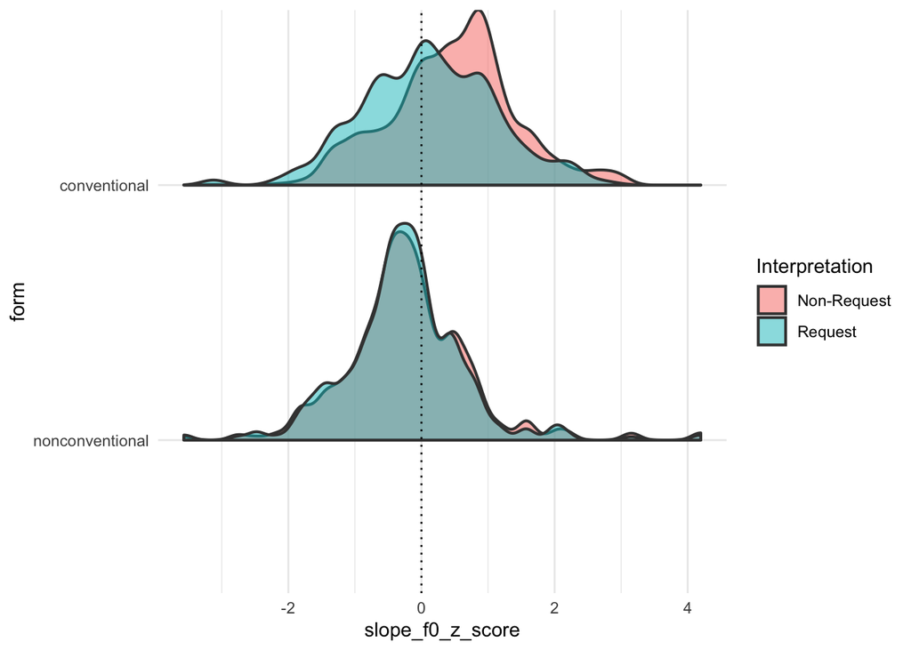

```r
df_merged_audio %>%
  ggplot(aes(x = slope_f0_z_score,
             y = form,
             fill = Interpretation)) +
  geom_density_ridges2(aes(height = ..density..),
                       color=gray(0.25), alpha = 0.5,
                       scale=0.85, size=0.75, stat="density") +
  geom_vline(xintercept = 0, linetype = "dotted") +
  theme_minimal()
```

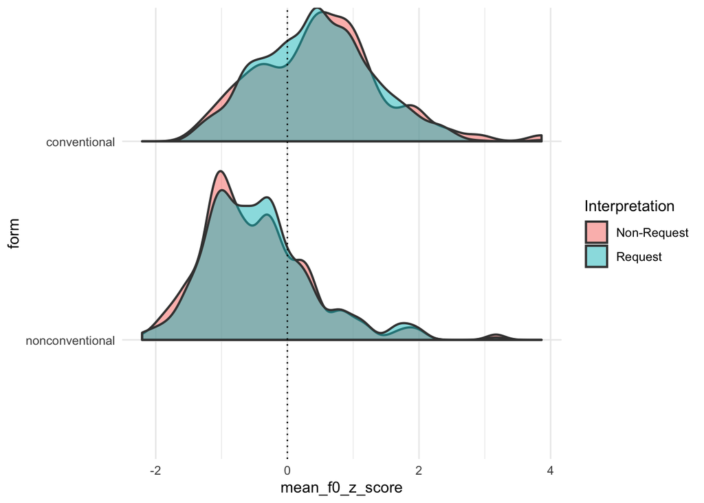

```r
df_merged_audio %>%
  ggplot(aes(x = mean_f0_z_score,
             y = form,
             fill = Interpretation)) +
  geom_density_ridges2(aes(height = ..density..),
                       color=gray(0.25), alpha = 0.5,
                       scale=0.85, size=0.75, stat="density") +
  geom_vline(xintercept = 0, linetype = "dotted") +
  theme_minimal()
```

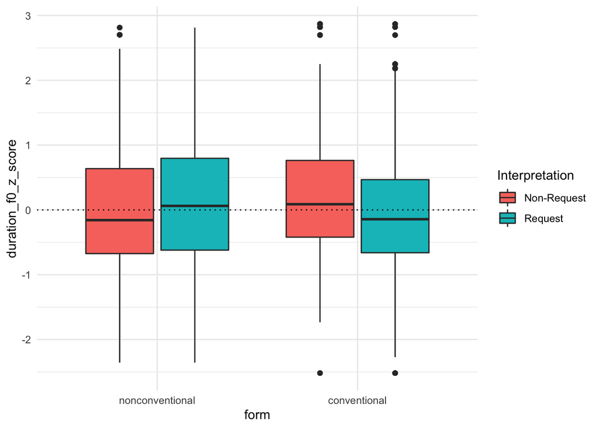

```r
df_merged_audio %>%
  ggplot(aes(x = form,
             y = duration_f0_z_score,
             fill = Interpretation)) +
  geom_boxplot() +
  geom_hline(yintercept = 0, linetype = "dotted") +
  theme_minimal()
```

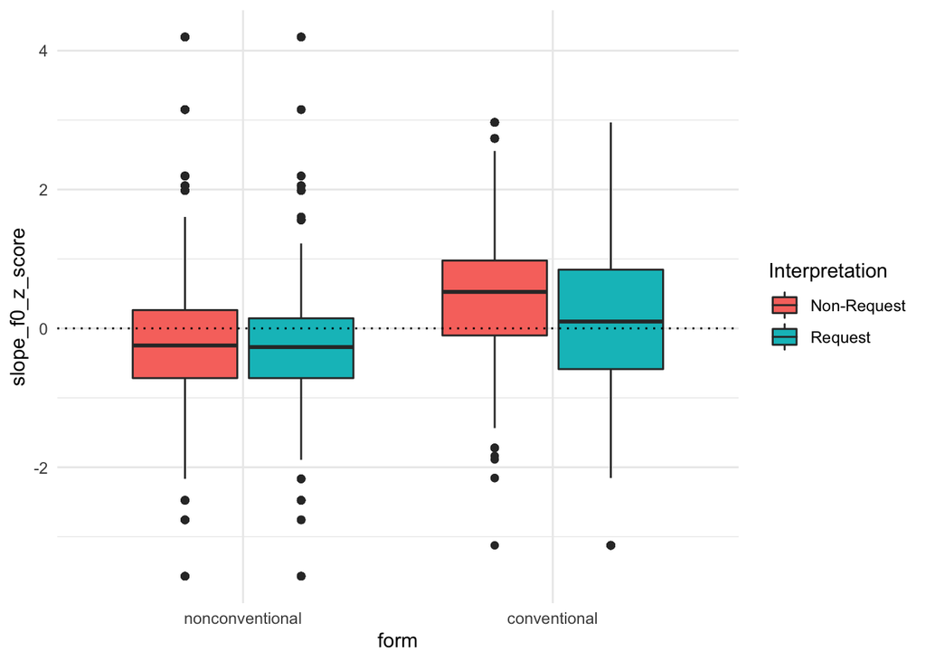

```r
df_merged_audio %>%
  ggplot(aes(x = form,
             y = slope_f0_z_score,
             fill = Interpretation)) +
  geom_boxplot() +
  geom_hline(yintercept = 0, linetype = "dotted") +
  theme_minimal()
```

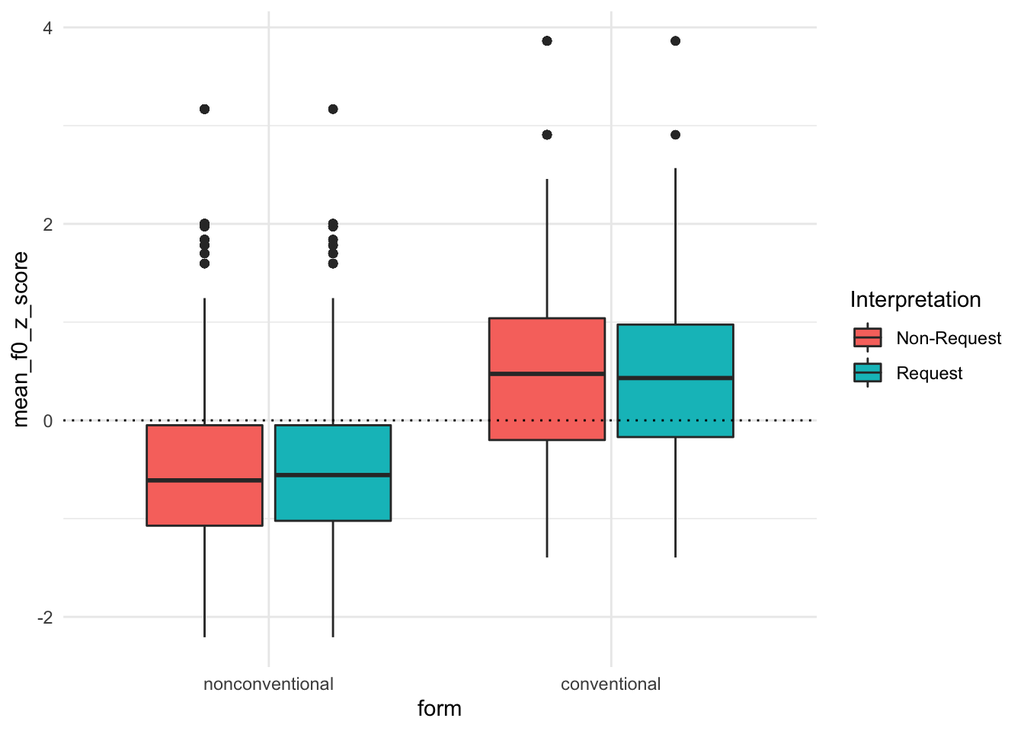

```r
df_merged_audio %>%
  ggplot(aes(x = form,
             y = mean_f0_z_score,
             fill = Interpretation)) +
  geom_boxplot() +
  geom_hline(yintercept = 0, linetype = "dotted") +
  theme_minimal()
```

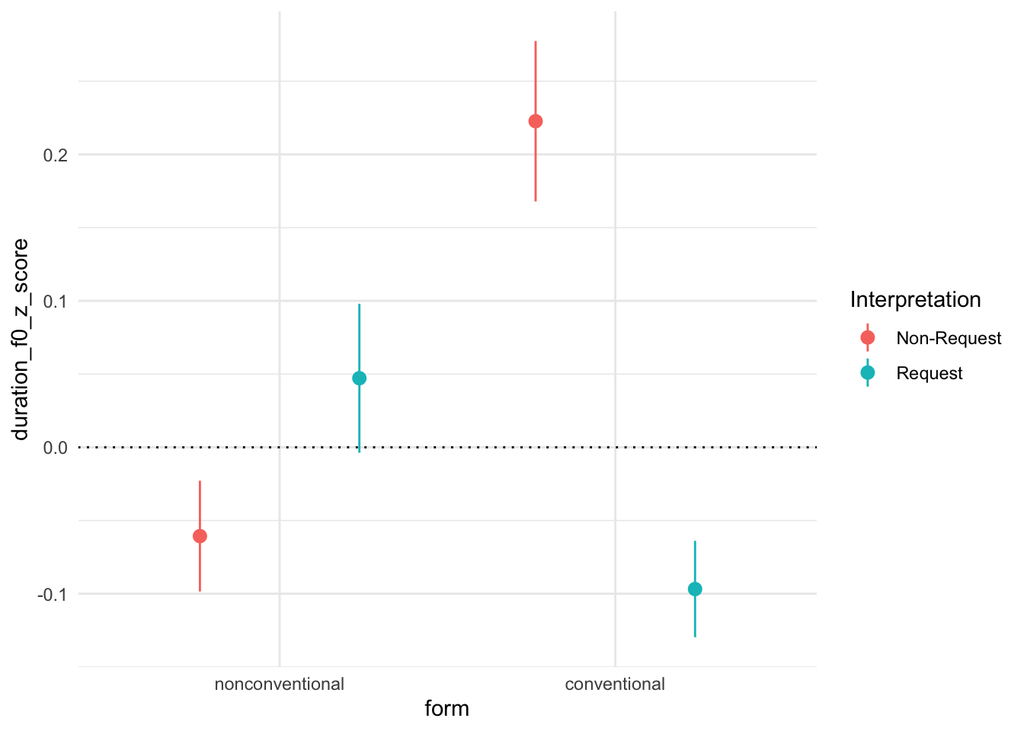

```r
df_merged_audio %>%
  ggplot(aes(x = form,
             y = duration_f0_z_score,
             color = Interpretation)) +
  stat_summary (fun = function(x){mean(x)},
                fun.min = function(x){mean(x) - 2*sd(x)/sqrt(length(x))},
                fun.max = function(x){mean(x) + 2*sd(x)/sqrt(length(x))},
                geom= 'pointrange',
                position=position_dodge(width=0.95)) +
  geom_hline(yintercept = 0, linetype = "dotted") +
  theme_minimal()
```

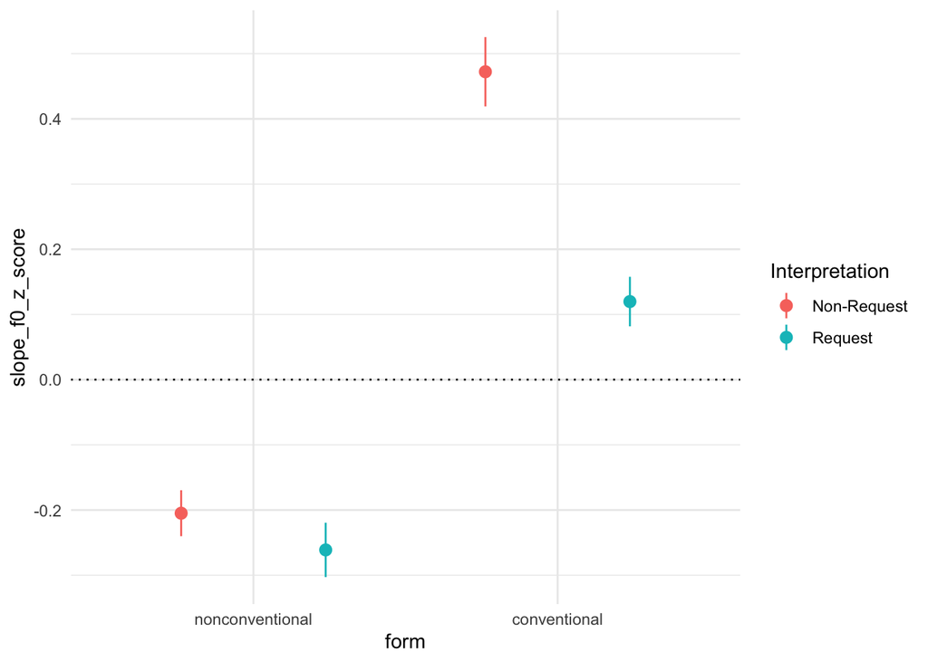

```r
df_merged_audio %>%
  ggplot(aes(x = form,
             y = slope_f0_z_score,
             color = Interpretation)) +
  stat_summary (fun = function(x){mean(x)},
                fun.min = function(x){mean(x) - 2*sd(x)/sqrt(length(x))},
                fun.max = function(x){mean(x) + 2*sd(x)/sqrt(length(x))},
                geom= 'pointrange',
                position=position_dodge(width=0.95)) +
  geom_hline(yintercept = 0, linetype = "dotted") +
  theme_minimal()
```

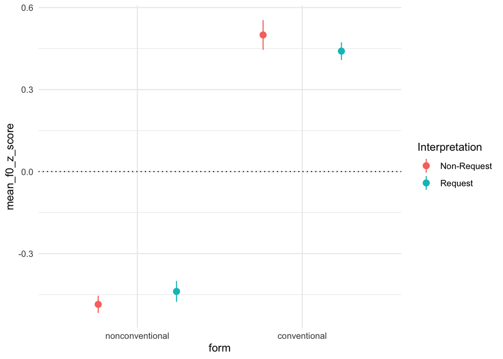

```r
df_merged_audio %>%
  ggplot(aes(x = form,
             y = mean_f0_z_score,
             color = Interpretation)) +
  stat_summary (fun = function(x){mean(x)},
                fun.min = function(x){mean(x) - 2*sd(x)/sqrt(length(x))},
                fun.max = function(x){mean(x) + 2*sd(x)/sqrt(length(x))},
                geom= 'pointrange',
                position=position_dodge(width=0.95)) +
  geom_hline(yintercept = 0, linetype = "dotted") +
  theme_minimal()
```

# Demographics (added to pre-registered file)

The original pre-registered file did not contain a section for reporting participant demographics. That is done here.

```r
df_demo = df_merged %>%
  group_by(subject, Gender, Native_Speaker, Age) %>%
  summarise(total_rt = sum(rt) / 1000)
table(df_demo$Gender)
```

```
##
##            Female              Male        Non-binary Prefer not to say
##                62                17                 1                 1
```

```r
table(df_demo$Native_Speaker)
```

```
##
## Yes
##  81
```

```r
mean(df_demo$Age, na.rm = TRUE)
```

```
## [1] 22.60494
```

```r
median(df_demo$Age, na.rm = TRUE)
```

```
## [1] 20
```

```r
sd(df_demo$Age, na.rm = TRUE)
```

```
## [1] 22.24448
```

```r
range(df_demo$Age, na.rm = TRUE)
```

```
## [1]  18 220
```

```r
## Average time
mean(df_demo$total_rt / 60)
```

```
## [1] 2.470929
```

```r
median(df_demo$total_rt / 60)
```

```
## [1] 1.791539
```

# Final visualizations (added to pre-registered file)

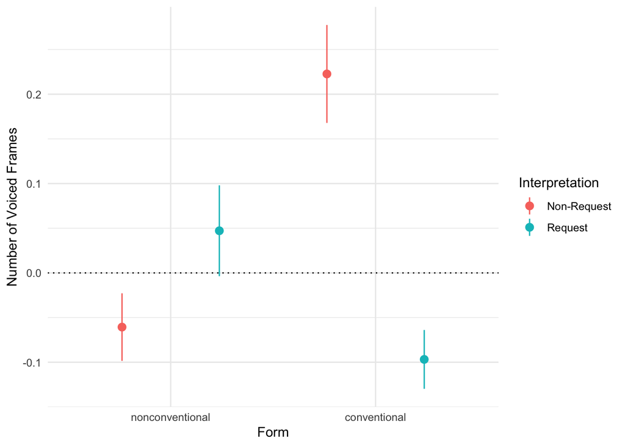

```r
df_merged_audio %>%
  ggplot(aes(x = form,
             y = duration_f0_z_score,
             color = Interpretation)) +
  stat_summary (fun = function(x){mean(x)},
                fun.min = function(x){mean(x) - 2*sd(x)/sqrt(length(x))},
                fun.max = function(x){mean(x) + 2*sd(x)/sqrt(length(x))},
                geom= 'pointrange',
                position=position_dodge(width=0.95)) +
  geom_hline(yintercept = 0, linetype = "dotted") +
  labs(x = "Form",
       y = "Number of Voiced Frames",
       color = "Interpretation") +
  theme_minimal()
```

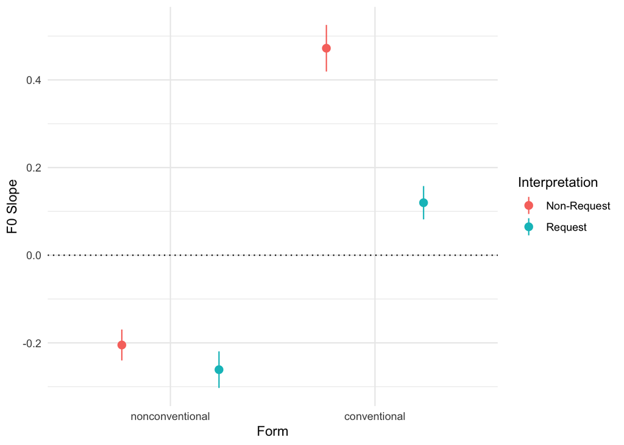

```r
ggsave("../../../Figures/exp_scaled_duration_interpretation.png", dpi = 300)
df_merged_audio %>%
  ggplot(aes(x = form,
             y = slope_f0_z_score,
             color = Interpretation)) +
  stat_summary (fun = function(x){mean(x)},
                fun.min = function(x){mean(x) - 2*sd(x)/sqrt(length(x))},
                fun.max = function(x){mean(x) + 2*sd(x)/sqrt(length(x))},
                geom= 'pointrange',
                position=position_dodge(width=0.95)) +
  geom_hline(yintercept = 0, linetype = "dotted") +
  labs(x = "Form",
       y = "F0 Slope",
       color = "Interpretation") +
  theme_minimal()
```

```r
ggsave("../../../Figures/exp_scaled_f0_slope_interpretation.png", dpi = 300)
```